# DASC 500: Introduction to Data Analytics

Clustering Algorithms

Maj Jason Freels PhD

28 February 2020

# Overview

## Introduction

- Clustering algorithms are a family of methods used to identify subgroups within a data set by classifying observations into similar categories
- We implement clustering algorithms because we want to partition the observations in such a way to help guide further analyses
- Since there isn’t a response variable, clustering is an example of **unsupervised** learning algorithms
- In this lecture we’ll look at two common types of clustering algorithms
  - K-Means clustering
  - Hierarchical clustering
- We’ll demonstrate these methods using the `Mall_Customers` data set which can be accessed from [**this site**](https://raw.githubusercontent.com/SteffiPeTaffy/machineLearningAZ/master/Machine%20Learning%20A-Z%20Template%20Folder/Part%204%20-%20Clustering/Section%2024%20-%20K-Means%20Clustering/Mall_Customers.csv)
- This data set contains 5 columns
  - `CustomerID`: Numeric identifier for each customer in the data set
  - `Genre`: Character string indicating the customer’s gender
  - `Annual Income (k$)`: The customer’s annual income (in thousands of dollars)
  - `Age`: Numeric variable of the customer’s age in years
  - `Spending Score (1-100)`: Numeric indicator of the customer’s spending habits

## Setting up the workspace

- To carry out this analysis you’ll need to import the following libraries and modules

```python
# for basic mathematics operation
import numpy as np
import pandas as pd
from pandas import plotting

# for visualizations
import matplotlib.pyplot as plt
import seaborn as sb
plt.style.use('fivethirtyeight')
fig = plt.gcf()
fig.set_size_inches(12, 8)
```

- With the packages imported, let’s read in the data from the URL provided above

```python
# importing the data set
data_url = "https://raw.githubusercontent.com/SteffiPeTaffy/machineLearningAZ/master/Machine%20Learning%20A-Z%20Template%20Folder/Part%204%20-%20Clustering/Section%2024%20-%20K-Means%20Clustering/Mall_Customers.csv"

df = pd.read_csv(data_url)
```

| CustomerID | Genre | Age | Annual Income (k$) | Spending Score (1-100) |
| --- | --- | --- | --- | --- |
| 1 | Male | 19 | 15 | 39 |
| 2 | Male | 21 | 15 | 81 |
| 3 | Female | 20 | 16 | 6 |
| 4 | Female | 23 | 16 | 77 |
| 5 | Female | 31 | 17 | 40 |
| 6 | Female | 22 | 17 | 76 |
| 7 | Female | 35 | 18 | 6 |
| 8 | Female | 23 | 18 | 94 |
| 9 | Male | 64 | 19 | 3 |
| 10 | Female | 30 | 19 | 72 |
| 11 | Male | 67 | 19 | 14 |
| 12 | Female | 35 | 19 | 99 |
| 13 | Female | 58 | 20 | 15 |
| 14 | Female | 24 | 20 | 77 |
| 15 | Male | 37 | 20 | 13 |
| 16 | Male | 22 | 20 | 79 |
| 17 | Female | 35 | 21 | 35 |
| 18 | Male | 20 | 21 | 66 |
| 19 | Male | 52 | 23 | 29 |
| 20 | Female | 35 | 23 | 98 |

- This data set has been partially cleaned to simplify our analysis, but in general the data should be prepared as follows:
  1. Ensure that each row contains one observation
  2. Ensure that each column contains a single variable
  3. Ensure that any missing values in the data are removed or can be estimated
  4. Ensure that the data are standardized to make variables comparable (this means that the variables are transformed such that they have a mean of zero and a standard deviation of one
- For step 3 we can check that there aren’t any “troublesome” values by invoking the `isnull()` function over the columns and rows in the data set

```python
# checking if there is any NULL data

df.isnull().any().any()
```

```
False
```

- For step 4, the data have not been standardized - let’s do that now
- For each column in our data set that contain numeric values we
  - Subtract from each value the mean of that column
  - Divide this result by the standard deviation of that column

```python
df_norm = df

df_norm.iloc[:,2] = (df.iloc[:,2] - df.iloc[:,2].mean()) / df.iloc[:,2].std()
df_norm.iloc[:,3] = (df.iloc[:,3] - df.iloc[:,3].mean()) / df.iloc[:,3].std()
df_norm.iloc[:,4] = (df.iloc[:,4] - df.iloc[:,4].mean()) / df.iloc[:,4].std()

df_norm
```

```
     CustomerID   Genre       Age  Annual Income (k$)  Spending Score (1-100)
0             1    Male -1.421003           -1.734646               -0.433713
1             2    Male -1.277829           -1.734646                1.192711
2             3  Female -1.349416           -1.696572               -1.711618
3             4  Female -1.134655           -1.696572                1.037814
4             5  Female -0.561958           -1.658498               -0.394989
..          ...     ...       ...                 ...                     ...
195         196  Female -0.275610            2.263112                1.115262
196         197  Female  0.440260            2.491555               -0.859681
197         198    Male -0.490371            2.491555                0.921640
198         199    Male -0.490371            2.910368               -1.246925
199         200    Male -0.633545            2.910368                1.270160

[200 rows x 5 columns]
```

- With the data prepared let’s dive in to clustering algorithms

# Clustering overview

## Distance Measures

- Clustering algorithms are implemented on at least two components (columns) in our data
  - The first component can be thought of as the `x` coordinate in an `x-y` plane
  - The second component can be thought of as the `y` coordinate in an `x-y` plane
- It’s important to understand that clustering algorithms pre-suppose a method used to compute the distance or the dissimilarity between each pair of observations
- The result of this computation is a dissimilarity or distance matrix
  - There are many methods to calculate this distance information
  - The choice of distance measures is a critical step in clustering and defines how the similarity of two elements (x, y) is calculated and it will influence the shape of the clusters
- Two classical methods for distance measures are *Euclidean* and *Manhattan distances*, which are defined as:
  - **Euclidean distance:** $d_{euc}(x,y) = \sqrt{\sum^n_{i=1}(x_i - y_i)^2}$
  - **Manhattan distance:** $d_{man}(x,y) = \sum^n_{i=1}|(x_i - y_i)|$
- Other dissimilarity measures exist such as correlation-based distances
- Correlation-based distance is defined by subtracting the correlation coefficient from $1$
- There are several different methods for computing correlation-based distances, such as:
  - **Pearson correlation distance**
  - **Spearman correlation distance**
  - **Kendall correlation distance**
- The choice of distance measures is very important, as it has a strong influence on the clustering results
- For many software tools, the default distance measure is the Euclidean distance
- However, depending on the type of the data and the research questions, other dissimilarity measures might be preferred and you should be aware of the options.
- In Python we can create the dissimilarity matrix using the functions [pdist()](https://docs.scipy.org/doc/scipy/reference/generated/scipy.spatial.distance.pdist.html) and [squareform()](https://docs.scipy.org/doc/scipy/reference/generated/scipy.spatial.distance.squareform.html#scipy.spatial.distance.squareform)

```python
from scipy.spatial.distance import squareform
from scipy.spatial.distance import pdist

dm = pd.DataFrame(squareform(pdist(df_norm.iloc[:, 2:])))

dm
```

```
          0         1         2    ...       197       198       199
0    0.000000  1.632714  1.280474  ...  4.534737  4.806615  5.009933
1    1.632714  0.000000  2.905460  ...  4.307476  5.305476  4.690123
2    1.280474  2.905460  0.000000  ...  5.021197  4.709331  5.534200
3    1.499612  0.214340  2.757806  ...  4.238987  5.182570  4.639935
4    0.863282  1.743290  1.534618  ...  4.354490  4.648167  4.863372
..        ...       ...       ...  ...       ...       ...       ...
195  4.437715  4.122197  4.982310  ...  0.368508  2.458657  0.755679
196  4.637513  5.002492  4.633481  ...  2.009772  1.091530  2.421711
197  4.534737  4.307476  5.021197  ...  0.000000  2.208638  0.563355
198  4.806615  5.305476  4.709331  ...  2.208638  0.000000  2.521154
199  5.009933  4.690123  5.534200  ...  0.563355  2.521154  0.000000

[200 rows x 200 columns]
```

## Clustering Algorithms

- **K-means clustering** is a relatively simple method used to cluster observations into a pre-specified set of `k` groups
- **Hierarchical clustering** is an alternative approach to k-means that does not require us to pre-specify the number of clusters
- These two methods are discussed further in the following sections

# K-means Clustering

## Overview

- The K-means clustering algorithm is one of the simplest and the most commonly used clustering algorithms used to partition a data set into a pre-specified set of `k` groups.
  - Partitions observations into `k` groups (clusters), such that objects within the same cluster are as similar as possible (i.e. have high intra-class similarity)
  - Objects from different clusters are as dissimilar as possible (i.e. have low inter-class similarity)
  - Each cluster is represented by its center (centroid) which corresponds to the mean of the observations assigned to the cluster
  - The number of clusters `k` is pre-specified by the analyst
  - The basic idea is to choose `k` so that the total intra-cluster variation (known as total within-cluster variation) is minimized
- The standard algorithm is the Hartigan-Wong algorithm (1979)
  - Each observation is assigned to one of `k` clusters
  - Defines the total within-cluster variation as the sum of squared distances Euclidean distances between items and the corresponding centroid
  - Algorithm stops after the sum of the squared distances between the observations to their assigned cluster centroids is minimized
  - $x_i$ represents the $i^{th}$ data point belonging to cluster $C_k$
  - $\mu_k$ is the mean value of the points assigned to the cluster $C_k$

$$W(C_k) = \sum_{x_i \in C_k}(x_i - \mu_k)^2$$

- We define the total within-cluster variation as follows:

$$tot.withiness = \sum^k_{k=1}W(C_k) = \sum^k_{k=1}\sum_{x_i \in C_k}(x_i - \mu_k)^2$$

- The *total within-cluster sum of square* measures the compactness (goodness) of the clustering and should ideally be as small as possible
- It should be noted that as stated [here](https://scikit-learn.org/stable/modules/generated/sklearn.cluster.KMeans.html) the default method used `sklearn.cluster.kmeans` is either Lloyd’s or Elkan’s algorithm
- For more on the differences between the algorithms check out [this site](https://stackoverflow.com/questions/20446053/k-means-lloyd-forgy-macqueen-hartigan-wong)

## K-Means steps

- K-means algorithm can be summarized as follows
  1. Specify the number of clusters (K) to be created (by the analyst)
  2. Select randomly k objects from the data set as the initial cluster centers or means
  3. Assigns each observation to their closest centroid, based on the Euclidean distance between the object and the centroid
  4. For each of the k clusters update the cluster centroid by calculating the new mean values of all the data points in the cluster. The centroid of a Kth cluster is a vector of length *p* containing the means of all variables for the observations in the kth cluster; *p* is the number of variables.
  5. Iterate steps 3 and 4 until the cluster assignments stop changing or the maximum number of iterations is reached
- The algorithm stops when the total within sum of squares value *converges* (the value in the iteration is the same that obtained in the previous iteration)

# Determining the Optimal number of Clusters using K-means

## Determining the number of clusters by visual inspection

- Since `k` must be set before we start the algorithm, analysts often examine the differences between several different values of `k`
- Before implementing a K-Means model, let’s look at our data using a `seaborn` scatter plot
  - Each individual is represented in the `x-y` plane
  - The `x` dimension represents the individual’s annual income
  - The `y` dimension represents the individual’s spending score

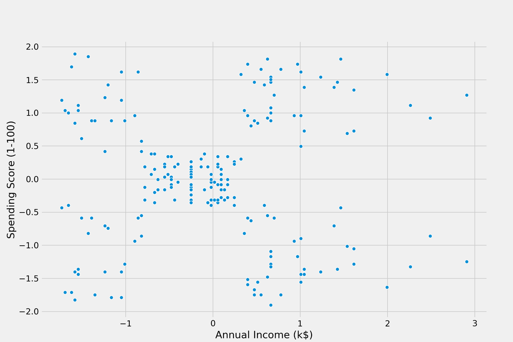

```python
plot = sb.scatterplot(x = "Annual Income (k$)",
                      y = "Spending Score (1-100)",
                      data = df_norm)
plt.show(plot)
```

- From the scatter plot there appears to be 5 groups (clusters) of spenders
- We can further investigate these spending by adding the individuals gender

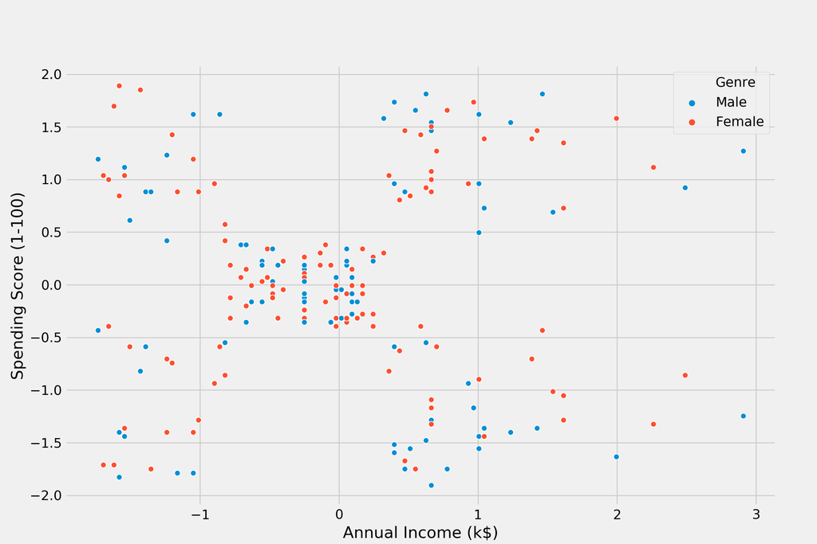

```python
plot = sb.scatterplot(x = "Annual Income (k$)",
                       y = "Spending Score (1-100)",
                       hue = "Genre",
                       data = df_norm)
plt.show(plot)
```

## Implementing k-means

- Now let’s implement a k-means model on each individual in the `Mall_Customers` data set
  - The `init = 'k-means++'` refers to the use of the [k-means++ algorithm](https://en.wikipedia.org/wiki/K-means%2B%2B) to choose initial values
  - For more on `n_init = 10` see [this link](https://stackoverflow.com/questions/46359490/python-scikit-learn-k-means-what-does-the-parameter-n-init-actually-do)

```python
from sklearn.cluster import KMeans

# define a KMeans model
km = KMeans(n_clusters = 5,
            init = 'k-means++',
            max_iter = 300,
            n_init = 10,
            random_state = 0)

# Define the values to which the KMeans model will be applied
vals = df_norm.iloc[:, [3, 4]].values

# Fit the model to the values
y_means = km.fit(vals)

# extract the total within-cluster sum of squares
km.inertia_
```

```
65.24056611493823
```

- The obvious question is: Is this a good result?
- The only way to tell with K-Means is by running the model using different values of `k` and noting how the total within-cluster sum of squares value changes
- Moreover, to aid the analyst the following list shows the three most popular methods for determining the optimal number of clusters
  1. **The Elbow method**
  2. The Silhouette method
  3. The Gap statistic

## Using the Elbow Method to find the optimal number of clusters

- Recall that the basic idea behind clustering methods is to find the number of clusters such that the total intra-cluster variation is minimized

$$\text{minimize}\Bigg(\sum^k_{k=1}W(C_k)\Bigg)$$

- Where $C_k$ is the $k^{th}$ cluster and $W(C_k)$ is the within-cluster variation
- The total within-cluster sum of square (wcss) measures the compactness of the clustering and we want it to be as small as possible
- Thus, we can use the following algorithm to define the optimal clusters:
  1. Compute clustering algorithm (e.g., k-means clustering) for different values of *k*. For instance, by varying *k* from 1 to 10 clusters
  2. For each *k*, calculate the total within-cluster sum of square (wcss)
  3. Plot the curve of wcss according to the number of clusters *k*
  4. The location of a bend (elbow) in the curve is generally considered as an indicator of the appropriate number of clusters
- We can implement this in Python with the following code – the results suggest that 5 is the optimal number of clusters as it appears to be the elbow in the curve

```python
from sklearn.cluster import KMeans

wcss = []
for i in range(1, 11):
    km = KMeans(n_clusters = i, init = 'k-means++', max_iter = 300,
                n_init = 10, random_state = 0)
    km.fit(vals)
    wcss.append(km.inertia_)
```

[output not shown]

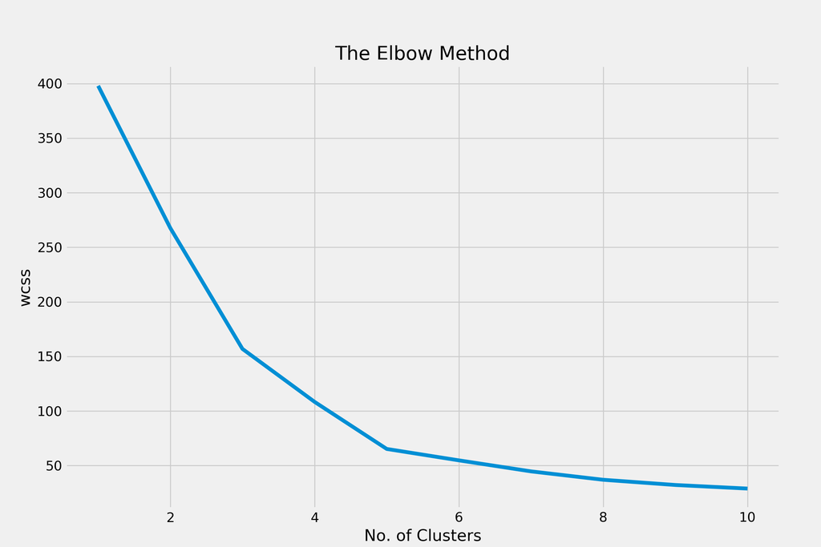

```python
plot1 = sb.lineplot(x = range(1, 11), y = wcss)
plot1.set_title('The Elbow Method', fontsize = 20)
plot1.set_xlabel('No. of Clusters')
plot1.set_ylabel('wcss')
plt.show(plot1)
```

- We also visualize the clusters using the following `matplotlib` code

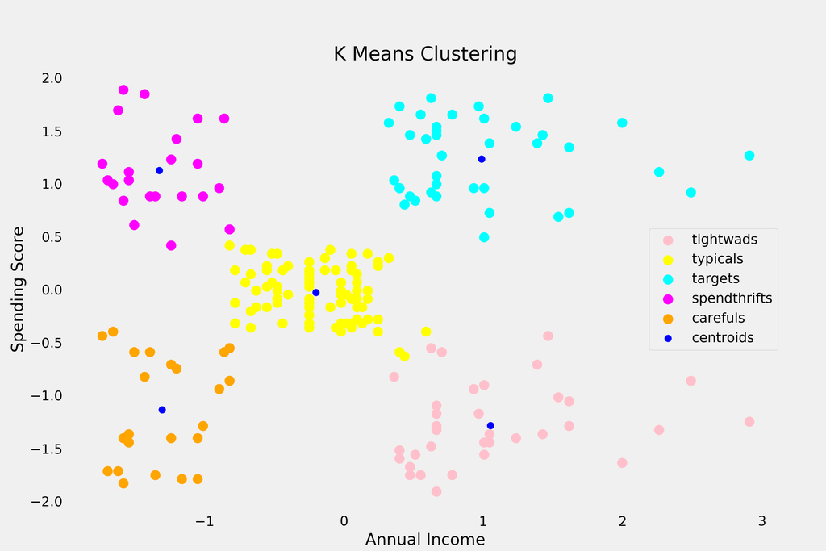

```python
km = KMeans(n_clusters = 5,
            init = 'k-means++',
            max_iter = 300,
            n_init = 10,
            random_state = 0)

y_means = km.fit_predict(vals)

plt.scatter(vals[y_means == 0, 0],
            vals[y_means == 0, 1],
            s = 100,
            c = 'pink',
            label = 'tightwads')

plt.scatter(vals[y_means == 1, 0],
            vals[y_means == 1, 1],
            s = 100,
            c = 'yellow',
            label = 'typicals')

plt.scatter(vals[y_means == 2, 0],
            vals[y_means == 2, 1],
            s = 100,
            c = 'cyan',
            label = 'targets')

plt.scatter(vals[y_means == 3, 0],
            vals[y_means == 3, 1],
            s = 100,
            c = 'magenta',
            label = 'spendthrifts')

plt.scatter(vals[y_means == 4, 0],
            vals[y_means == 4, 1],
            s = 100,
            c = 'orange',
            label = 'carefuls')

plt.scatter(km.cluster_centers_[:,0],
            km.cluster_centers_[:,1],
            s = 50,
            c = 'blue',
            label = 'centroids')

plt.style.use('fivethirtyeight')
plt.title('K Means Clustering', fontsize = 20)
plt.xlabel('Annual Income')
plt.ylabel('Spending Score')
plt.legend()
plt.grid()
plt.show()
```

- Here’s how to recreate the same plot using `seaborn` - much cleaner

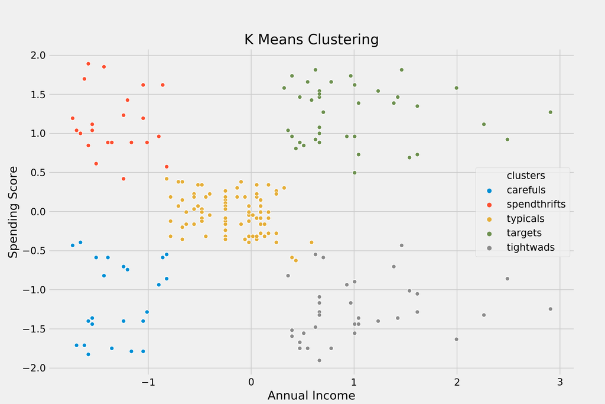

```python
km = KMeans(n_clusters = 5,
            init = 'k-means++',
            max_iter = 300,
            n_init = 10,
            random_state = 0)

y_means = km.fit_predict(vals)

df2 = df_norm
df2["clusters"] = "people"

df2.loc[y_means == 0, "clusters"] = "tightwads"
df2.loc[y_means == 1, "clusters"] = "typicals"
df2.loc[y_means == 2, "clusters"] = "targets"
df2.loc[y_means == 3, "clusters"] = "spendthrifts"
df2.loc[y_means == 4, "clusters"] = "carefuls"

plot2 = sb.scatterplot(x = "Annual Income (k$)",
                       y = "Spending Score (1-100)",
                       hue = 'clusters',
                       data = df2)

plot2.set_title('K Means Clustering', fontsize = 20)
plot2.set_xlabel('Annual Income')
plot2.set_ylabel('Spending Score')
plt.show(plot2)
```

- This result gives a clear insight about the different segments of the customers in the data set
  - There are clearly 5 types of customers
  - These customer types are based on each customer’s annual income and spending habits
  - We refer to the customers in each of these clusters as tightwads, typicals, targets, spendthrifts, and carefuls

## Clusters of Customers Based on their Ages

- Suppose now that we wanted to group customers based on their age and spending habits
- This can easily be done by defining a second set of values which include columns 2 and 4 from the original `DataFrame`

```python
vals2 = df_norm.iloc[:, [2, 4]].values
```

- Implementing the K-means algorithm on this new set of values can be done in the same manner as was shown previously

```python
from sklearn.cluster import KMeans

wcss = []
for i in range(1, 11):
    kmeans = KMeans(n_clusters = i, init = 'k-means++', max_iter = 300, n_init = 10, random_state = 0)
    kmeans.fit(vals2)
    wcss.append(kmeans.inertia_)
```

[output not shown]

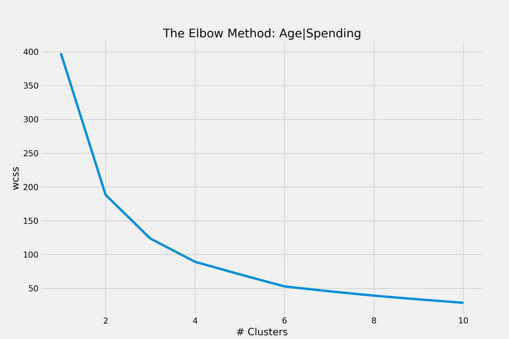

```python
plot3 = sb.lineplot(x = range(1, 11), y = wcss)
plot3.set_title('The Elbow Method: Age|Spending', fontsize = 20)
plot3.set_xlabel('# Clusters')
plot3.set_ylabel('wcss')
plt.show(plot3)
```

- Considering customer age and spending habits we see that there are now 4 types of customer
- We can visualize these type of customer using the code below

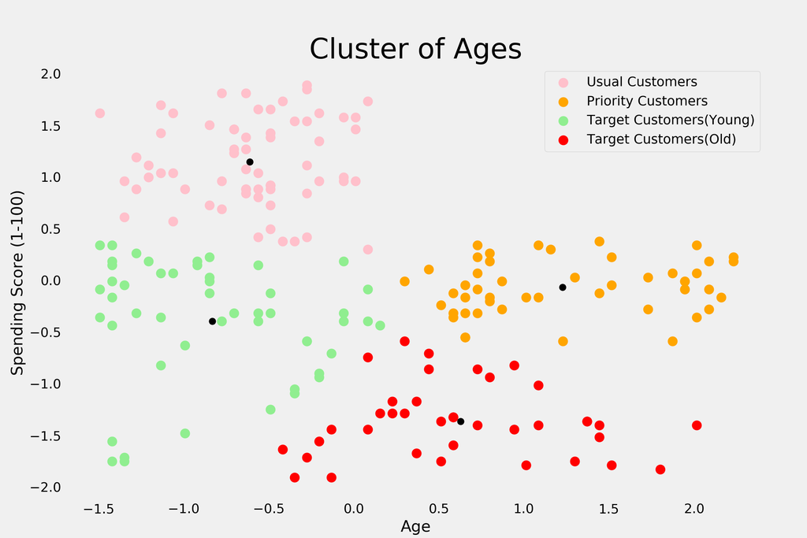

```python
kmeans = KMeans(n_clusters = 4,
                init = 'k-means++',
                max_iter = 300,
                n_init = 10,
                random_state = 0)

ymeans = kmeans.fit_predict(vals2)

plt.rcParams['figure.figsize'] = (10, 10)
plt.title('Cluster of Ages', fontsize = 30)

plt.scatter(vals2[ymeans == 0, 0],
            vals2[ymeans == 0, 1],
            s = 100,
            c = 'pink',
            label = 'Usual Customers')

plt.scatter(vals2[ymeans == 1, 0],
            vals2[ymeans == 1, 1],
            s = 100,
            c = 'orange',
            label = 'Priority Customers')

plt.scatter(vals2[ymeans == 2, 0],
            vals2[ymeans == 2, 1],
            s = 100,
            c = 'lightgreen',
            label = 'Target Customers(Young)')

plt.scatter(vals2[ymeans == 3, 0],
            vals2[ymeans == 3, 1],
            s = 100,
            c = 'red',
            label = 'Target Customers(Old)')

plt.scatter(kmeans.cluster_centers_[:, 0],
            kmeans.cluster_centers_[:, 1],
            s = 50,
            c = 'black')

plt.style.use('fivethirtyeight')
plt.xlabel('Age')
plt.ylabel('Spending Score (1-100)')
plt.legend()
plt.grid()
plt.show()
```

- We refer to these clusters as Usual Customers, Priority Customers, Senior Citizen Target Customers, Young Target Customers
- These results help us to develop marketing strategies to target the members of these clusters

# Heirarchical Clustering

## Overview

- Hierarchical clustering is an algorithm that groups similar objects into groups called clusters
- The endpoint is a set of clusters, where each cluster is distinct from each other cluster, and the objects within each cluster are broadly similar to each other
- The results are often visualized as a dendrogram, which is a nested collection of groups that looks similar to a tree

## Maximum or complete linkage method

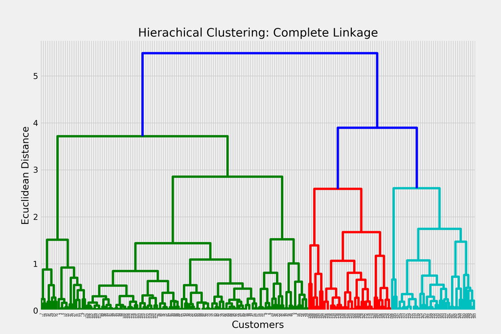

```python
import scipy.cluster.hierarchy as sch

dendrogram = sch.dendrogram(sch.linkage(vals, method = 'complete'))
plt.title('Hierachical Clustering: Complete Linkage', fontsize = 20)
plt.xlabel('Customers')
plt.ylabel('Ecuclidean Distance')
plt.show()
```

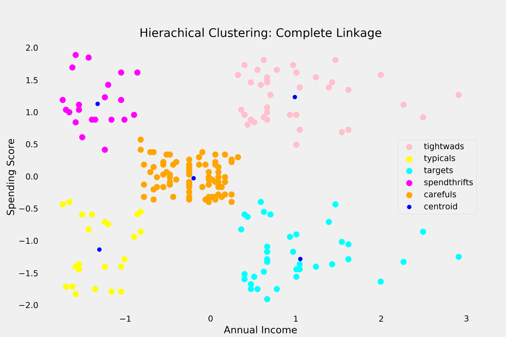

```python
from sklearn.cluster import AgglomerativeClustering

hc = AgglomerativeClustering(n_clusters = 5,
                             affinity = 'euclidean',
                             linkage = 'complete')

y_hc = hc.fit_predict(vals)

plt.scatter(vals[y_hc == 0, 0],
            vals[y_hc == 0, 1],
            s = 100,
            c = 'pink',
            label = "tightwads")

plt.scatter(vals[y_hc == 1, 0],
            vals[y_hc == 1, 1],
            s = 100,
            c = 'yellow',
            label = "typicals")

plt.scatter(vals[y_hc == 2, 0],
            vals[y_hc == 2, 1],
            s = 100,
            c = 'cyan',
            label = 'targets')

plt.scatter(vals[y_hc == 3, 0],
            vals[y_hc == 3, 1],
            s = 100,
            c = 'magenta',
            label = 'spendthrifts')

plt.scatter(vals[y_hc == 4, 0],
            vals[y_hc == 4, 1],
            s = 100,
            c = 'orange',
            label = 'carefuls')

plt.scatter(km.cluster_centers_[:,0],
            km.cluster_centers_[:,1],
            s = 50,
            c = 'blue',
            label = 'centroid')

plt.style.use('fivethirtyeight')
plt.title('Hierachical Clustering: Complete Linkage', fontsize = 20)
plt.xlabel('Annual Income')
plt.ylabel('Spending Score')
plt.legend()
plt.grid()
plt.show()
```

## Minimum or single linkage method

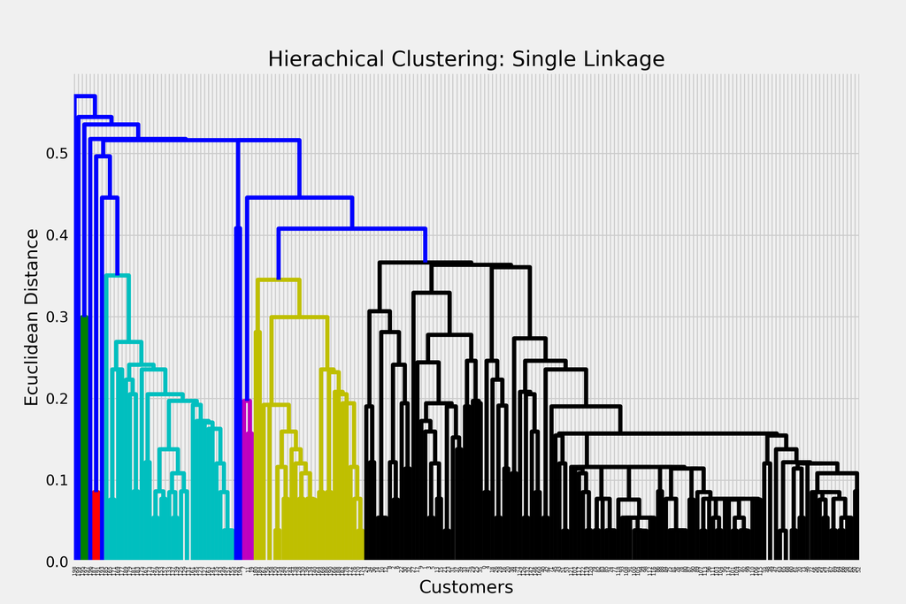

```python
import scipy.cluster.hierarchy as sch

dendrogram = sch.dendrogram(sch.linkage(vals, method = 'single'))
plt.title('Hierachical Clustering: Single Linkage', fontsize = 20)
plt.xlabel('Customers')
plt.ylabel('Ecuclidean Distance')
plt.show()
```

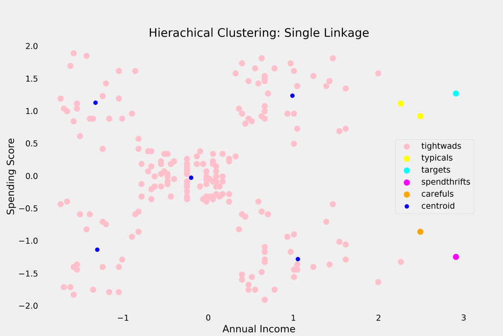

```python
from sklearn.cluster import AgglomerativeClustering

hc = AgglomerativeClustering(n_clusters = 5,
                             affinity = 'euclidean',
                             linkage = 'single')

y_hc = hc.fit_predict(vals)

plt.scatter(vals[y_hc == 0, 0],
            vals[y_hc == 0, 1],
            s = 100,
            c = 'pink',
            label = "tightwads")

plt.scatter(vals[y_hc == 1, 0],
            vals[y_hc == 1, 1],
            s = 100,
            c = 'yellow',
            label = "typicals")

plt.scatter(vals[y_hc == 2, 0],
            vals[y_hc == 2, 1],
            s = 100,
            c = 'cyan',
            label = 'targets')

plt.scatter(vals[y_hc == 3, 0],
            vals[y_hc == 3, 1],
            s = 100,
            c = 'magenta',
            label = 'spendthrifts')

plt.scatter(vals[y_hc == 4, 0],
            vals[y_hc == 4, 1],
            s = 100,
            c = 'orange',
            label = 'carefuls')

plt.scatter(km.cluster_centers_[:,0],
            km.cluster_centers_[:,1],
            s = 50,
            c = 'blue',
            label = 'centroid')

plt.style.use('fivethirtyeight')
plt.title('Hierachical Clustering: Single Linkage', fontsize = 20)
plt.xlabel('Annual Income')
plt.ylabel('Spending Score')
plt.legend()
plt.grid()
plt.show()
```

## Mean or average linkage method

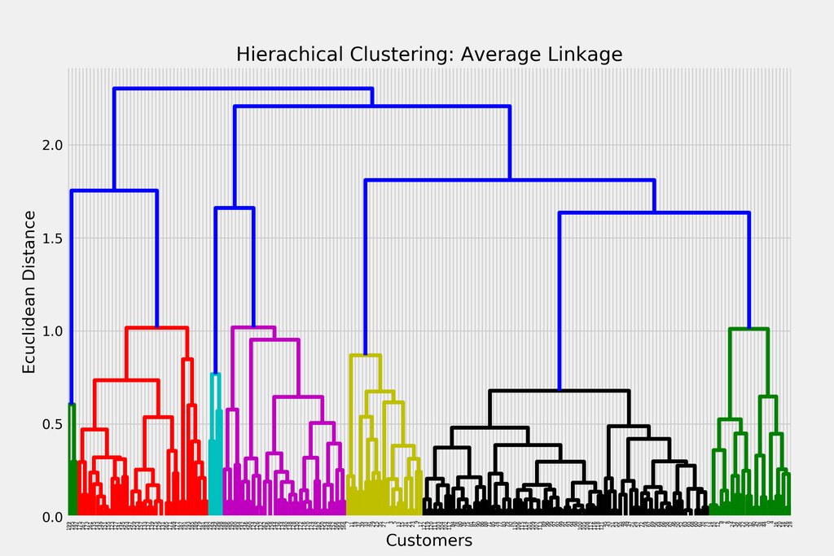

```python
import scipy.cluster.hierarchy as sch

dendrogram = sch.dendrogram(sch.linkage(vals, method = 'average'))
plt.title('Hierachical Clustering: Average Linkage', fontsize = 20)
plt.xlabel('Customers')
plt.ylabel('Ecuclidean Distance')
plt.show()
```

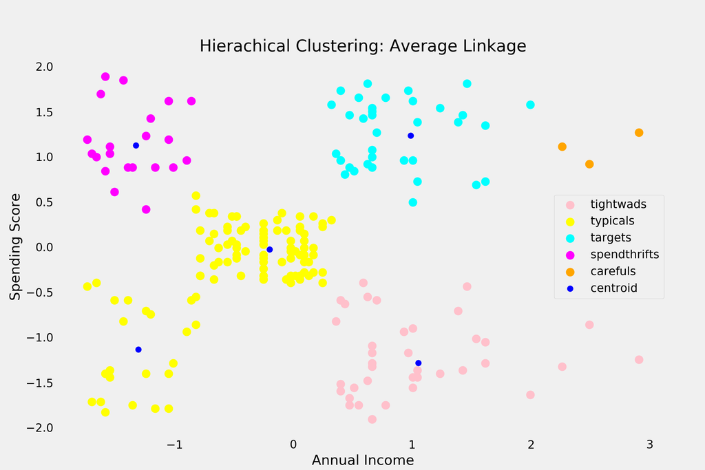

```python
from sklearn.cluster import AgglomerativeClustering

hc = AgglomerativeClustering(n_clusters = 5,
                             affinity = 'euclidean',
                             linkage = 'average')

y_hc = hc.fit_predict(vals)

plt.scatter(vals[y_hc == 0, 0],
            vals[y_hc == 0, 1],
            s = 100,
            c = 'pink',
            label = "tightwads")

plt.scatter(vals[y_hc == 1, 0],
            vals[y_hc == 1, 1],
            s = 100,
            c = 'yellow',
            label = "typicals")

plt.scatter(vals[y_hc == 2, 0],
            vals[y_hc == 2, 1],
            s = 100,
            c = 'cyan',
            label = 'targets')

plt.scatter(vals[y_hc == 3, 0],
            vals[y_hc == 3, 1],
            s = 100,
            c = 'magenta',
            label = 'spendthrifts')

plt.scatter(vals[y_hc == 4, 0],
            vals[y_hc == 4, 1],
            s = 100,
            c = 'orange',
            label = 'carefuls')

plt.scatter(km.cluster_centers_[:,0],
            km.cluster_centers_[:,1],
            s = 50,
            c = 'blue',
            label = 'centroid')

plt.style.use('fivethirtyeight')
plt.title('Hierachical Clustering: Average Linkage', fontsize = 20)
plt.xlabel('Annual Income')
plt.ylabel('Spending Score')
plt.legend()
plt.grid()
plt.show()
```

## Centroid linkage method

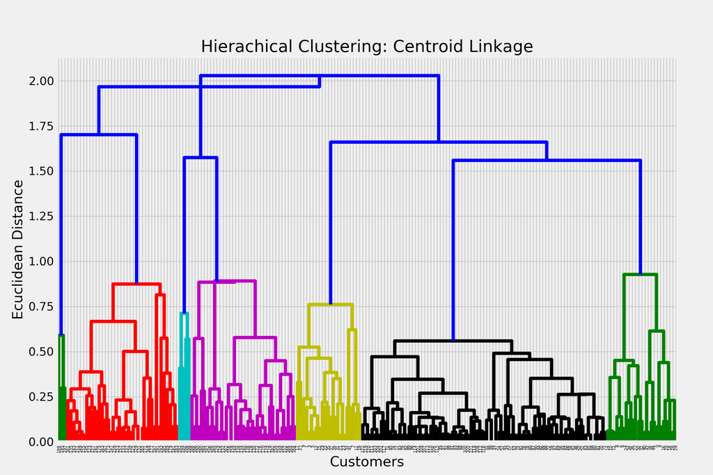

```python
import scipy.cluster.hierarchy as sch

dendrogram = sch.dendrogram(sch.linkage(vals, method = 'centroid'))
plt.title('Hierachical Clustering: Centroid Linkage', fontsize = 20)
plt.xlabel('Customers')
plt.ylabel('Ecuclidean Distance')
plt.show()
```

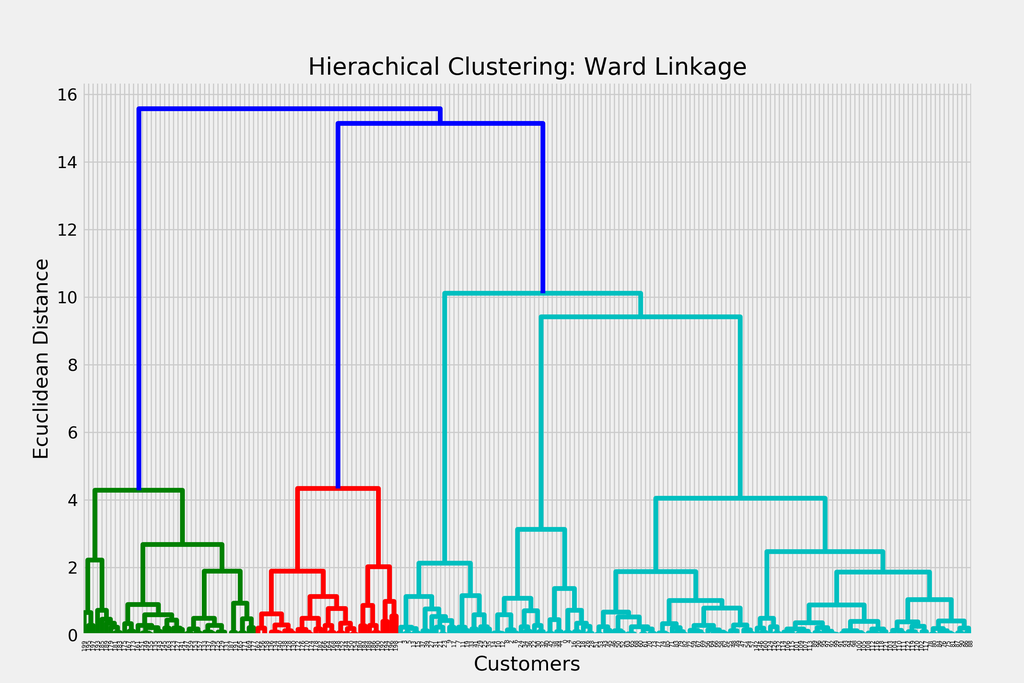

```python
import scipy.cluster.hierarchy as sch

dendrogram = sch.dendrogram(sch.linkage(vals, method = 'ward'))
plt.title('Hierachical Clustering: Ward Linkage', fontsize = 20)
plt.xlabel('Customers')
plt.ylabel('Ecuclidean Distance')
plt.show()
```

- We can further visualize the results of hierarchical clustering

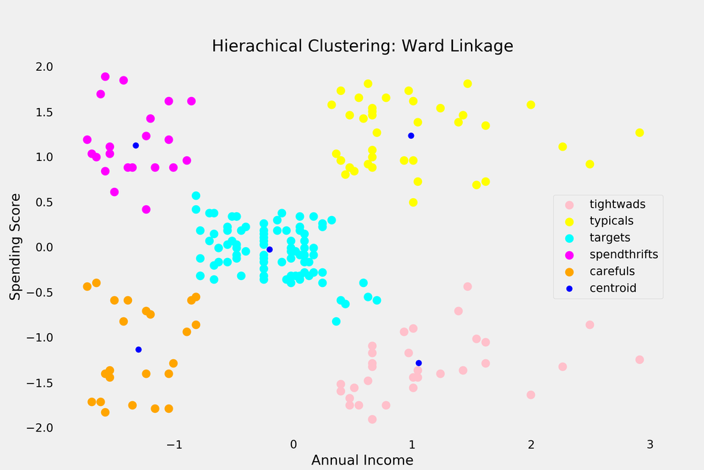

```python
from sklearn.cluster import AgglomerativeClustering

hc = AgglomerativeClustering(n_clusters = 5,
                             affinity = 'euclidean',
                             linkage = 'ward')

y_hc = hc.fit_predict(vals)

plt.scatter(vals[y_hc == 0, 0],
            vals[y_hc == 0, 1],
            s = 100,
            c = 'pink',
            label = "tightwads")

plt.scatter(vals[y_hc == 1, 0],
            vals[y_hc == 1, 1],
            s = 100,
            c = 'yellow',
            label = "typicals")

plt.scatter(vals[y_hc == 2, 0],
            vals[y_hc == 2, 1],
            s = 100,
            c = 'cyan',
            label = 'targets')

plt.scatter(vals[y_hc == 3, 0],
            vals[y_hc == 3, 1],
            s = 100,
            c = 'magenta',
            label = 'spendthrifts')

plt.scatter(vals[y_hc == 4, 0],
            vals[y_hc == 4, 1],
            s = 100,
            c = 'orange',
            label = 'carefuls')

plt.scatter(km.cluster_centers_[:,0],
            km.cluster_centers_[:,1],
            s = 50,
            c = 'blue',
            label = 'centroid')

plt.style.use('fivethirtyeight')
plt.title('Hierachical Clustering: Ward Linkage', fontsize = 20)
plt.xlabel('Annual Income')
plt.ylabel('Spending Score')
plt.legend()
plt.grid()
plt.show()
```